# Reproducible Research Project

##Introduction It is now possible to collect a large amount of data about personal movement using activity monitoring devices such as a Fitbit, Nike Fuelband, or Jawbone Up. These type of devices are part of the “quantified self” movement – a group of enthusiasts who take measurements about themselves regularly to improve their health, to find patterns in their behavior, or because they are tech geeks. But these data remain under-utilized both because the raw data are hard to obtain and there is a lack of statistical methods and software for processing and interpreting the data.

This assignment makes use of data from a personal activity monitoring device. This device collects data at 5 minute intervals through out the day. The data consists of two months of data from an anonymous individual collected during the months of October and November, 2012 and include the number of steps taken in 5 minute intervals each day.

##Dataset The data for this assignment can be downloaded from the course web site:

Dataset: Activity monitoring data [52K] The variables included in this dataset are:

steps: Number of steps taking in a 5-minute interval (missing values are coded as NA)

date: The date on which the measurement was taken in YYYY-MM-DD format

interval: Identifier for the 5-minute interval in which measurement was taken

The dataset is stored in a comma-separated-value (CSV) file and there are a total of 17,568 observations in this dataset.

## 1. Loading and Preprocessing the data

```r
activity <- read.csv("C:/Users/Tori Tori/Downloads/coursera/reproducible research/repdata_data_activity/activity.csv")
```

## 2. What is mean total number of steps taken per day?

# Histogram of the total number of steps taken every day

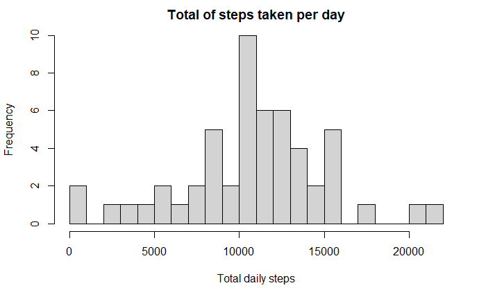

```r
hist(tapply(activity$steps, activity$date, sum), xlab = "Total daily steps", breaks = 20,
    main = "Total of steps taken per day")
```

#Calculate and report the mean and median total number of steps taken per day

```r
total.daily.steps <- as.numeric(tapply(activity$steps, activity$date, sum))
step.mean <- mean(total.daily.steps, na.rm = TRUE)
step.median <- median(total.daily.steps, na.rm = TRUE)

step.mean
```

```
[1] 10766.19
```

```r
step.median
```

```
[1] 10765
```

## 3. What is the average daily activity pattern?

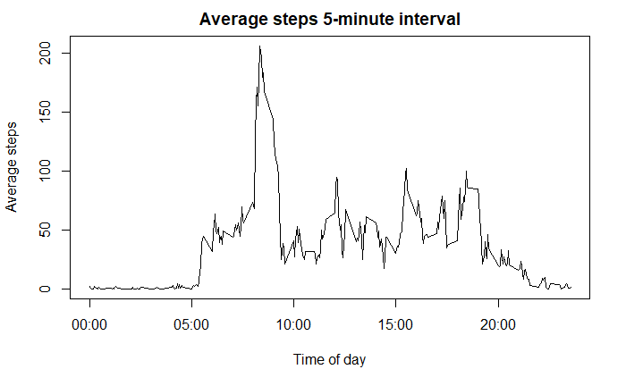

```r
activity$interval <- as.factor(as.character(activity$interval))
interval.mean <- as.numeric(tapply(activity$steps, activity$interval, mean, na.rm = TRUE))
intervals <- data.frame(intervals = as.numeric(levels(activity$interval)), interval.mean)
intervals <- intervals[order(intervals$intervals), ]

labels <- c("00:00", "05:00", "10:00", "15:00", "20:00")
labels.at <- seq(0, 2000, 500)
plot(intervals$intervals, intervals$interval.mean, type = "l", main = "Average steps 5-minute interval",
    ylab = "Average steps", xlab = "Time of day", xaxt = "n")
axis(side = 1, at = labels.at, labels = labels)
```

```r
intervals.sorted <- intervals[order(intervals$interval.mean, decreasing = TRUE),
    ]
max.interval <- intervals.sorted$intervals[1[1]]
max.interval
```

```
[1] 835
```

## 4. Imputing missing values

```r
dim(activity[is.na(activity$steps), ])[1]
```

```
[1] 2304
```

# The total number of missing values in the dataset is 2304.

# The strategy for filling in all of the missing values in the dataset is to change the “NA”s to the mean values for that 5-minute interval.

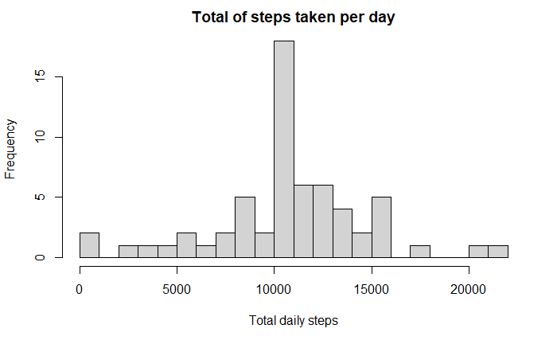

```r
steps <- vector()
for (i in 1:dim(activity)[1]) {
    if (is.na(activity$steps[i])) {
        steps <- c(steps, intervals$interval.mean[intervals$intervals == activity$interval[i]])
    } else {
        steps <- c(steps, activity$steps[i])
    }
}


activity.without.missing.data <- data.frame(steps = steps, date = activity$date,
    interval = activity$interval)
hist(tapply(activity.without.missing.data$steps, activity.without.missing.data$date,
    sum), xlab = "Total daily steps", breaks = 20, main = "Total of steps taken per day")
```

```r
total.daily.steps <- as.numeric(tapply(activity.without.missing.data$steps,
    activity.without.missing.data$date, sum))
step.mean <- mean(total.daily.steps)
step.median <- median(total.daily.steps)
step.mean
```

```
[1] 10766.19
```

```r
step.median
```

```
[1] 10766.19
```

## 5. Are there differences in activity patterns between weekdays and weekends?

```r
activity.without.missing.data$day.type <- c("weekend", "weekday", "weekday",
    "weekday", "weekday", "weekday", "weekend")[as.POSIXlt(activity.without.missing.data$date)$wday +
    1]
activity.without.missing.data$day.type <- as.factor(activity.without.missing.data$day.type)

weekday <- activity.without.missing.data[activity.without.missing.data$day.type ==
    "weekday", ]
weekend <- activity.without.missing.data[activity.without.missing.data$day.type ==
    "weekend", ]
weekday.means <- as.numeric(tapply(weekday$steps, weekday$interval, mean))
weekend.means <- as.numeric(tapply(weekend$steps, weekend$interval, mean))

intervals.day.type <- data.frame(intervals = as.numeric(levels(activity$interval)),
    weekday.means, weekend.means)
intervals.day.type <- intervals.day.type[order(intervals.day.type$intervals),
    ]
```

```r
par <- par(mfrow = c(2, 1))
plot(intervals.day.type$intervals, intervals.day.type$weekday.means, type = "l",
    col = "red", ylab = "Average steps", xlab = "Time of day", main = "Average steps 5-minute interval at weekday",
    xaxt = "n")
axis(side = 1, at = labels.at, labels = labels)
```

[figure not shown]

```r
plot(intervals.day.type$intervals, intervals.day.type$weekend.means, type = "l",
    col = "blue", ylab = "Average steps", xlab = "Time of day", main = "Average steps 5-minute interval at weekend",
    xaxt = "n")
axis(side = 1, at = labels.at, labels = labels)
```

[output not shown]